# Ensemble_Techniques_Project

### Importing the libraries

```python
import numpy as np
import pandas as pd

import matplotlib.pyplot as plt
import seaborn as sns

%matplotlib inline
import warnings
warnings.filterwarnings('ignore')

pd.set_option('display.max_columns', 50)

import time
```

### 1.a) Reading the first dataset

```python
df1 = pd.read_csv(r'C:\Users\Jupally Pavan Kumar\Downloads\TelcomCustomer-Churn_1.csv')
```

```python
df1.shape
```

```
(7043, 10)
```

### 1.b) Reading the second dataset

```python
df2 = pd.read_csv(r'C:\Users\Jupally Pavan Kumar\Downloads\TelcomCustomer-Churn_2.csv')
```

```python
df2.shape
```

```
(7043, 12)
```

### 1.c) Merging two datasets into a single dataset

```python
churn = pd.merge(df1, df2, on = 'customerID')
```

### 1.d) Let's check the columns

```python
df_cols = [col for col in df1.columns] + [col for col in df2.columns]
df_cols.pop(10)
churn_cols = [col for col in churn.columns]
if df_cols == churn_cols:
    print("All Columns are incorporated properly.")
else:
    print("Columns are not incorporated properly.")
```

```
All Columns are incorporated properly.
```

```python
churn.shape
```

```
(7043, 21)
```

```python
churn.head()
```

|  | customerID | gender | SeniorCitizen | Partner | Dependents | tenure | PhoneService | MultipleLines | InternetService | OnlineSecurity | OnlineBackup | DeviceProtection | TechSupport | StreamingTV | StreamingMovies | Contract | PaperlessBilling | PaymentMethod | MonthlyCharges | TotalCharges | Churn |
| --- | --- | --- | --- | --- | --- | --- | --- | --- | --- | --- | --- | --- | --- | --- | --- | --- | --- | --- | --- | --- | --- |
| 0 | 7590-VHVEG | Female | 0 | Yes | No | 1 | No | No phone service | DSL | No | Yes | No | No | No | No | Month-to-month | Yes | Electronic check | 29.85 | 29.85 | No |
| 1 | 5575-GNVDE | Male | 0 | No | No | 34 | Yes | No | DSL | Yes | No | Yes | No | No | No | One year | No | Mailed check | 56.95 | 1889.5 | No |
| 2 | 3668-QPYBK | Male | 0 | No | No | 2 | Yes | No | DSL | Yes | Yes | No | No | No | No | Month-to-month | Yes | Mailed check | 53.85 | 108.15 | Yes |
| 3 | 7795-CFOCW | Male | 0 | No | No | 45 | No | No phone service | DSL | Yes | No | Yes | Yes | No | No | One year | No | Bank transfer (automatic) | 42.30 | 1840.75 | No |
| 4 | 9237-HQITU | Female | 0 | No | No | 2 | Yes | No | Fiber optic | No | No | No | No | No | No | Month-to-month | Yes | Electronic check | 70.70 | 151.65 | Yes |

### 2.a) Let's look at the missing and unexpected values

```python
churn.isnull().sum()
```

```
customerID          0
gender              0
SeniorCitizen       0
Partner             0
Dependents          0
tenure              0
PhoneService        0
MultipleLines       0
InternetService     0
OnlineSecurity      0
OnlineBackup        0
DeviceProtection    0
TechSupport         0
StreamingTV         0
StreamingMovies     0
Contract            0
PaperlessBilling    0
PaymentMethod       0
MonthlyCharges      0
TotalCharges        0
Churn               0
dtype: int64
```

- There are no null values in the data set.

```python
for i in churn.columns:
    total = 0
    total = sum(churn[i] == ' ')
    if total >0:
        print(f"'{i}' has {total} unexpected values.")
```

```
'TotalCharges' has 11 unexpected values.
```

- Let's impute these unexpected values with 'NaN'.

```python
churn['TotalCharges'] = churn['TotalCharges'].replace(' ', np.nan)
```

- Now let's impute these null values with median.

```python
churn['TotalCharges'] = churn['TotalCharges'].fillna(churn['TotalCharges'].median())
```

```python
churn.describe().T
```

|  | count | mean | std | min | 25% | 50% | 75% | max |
| --- | --- | --- | --- | --- | --- | --- | --- | --- |
| SeniorCitizen | 7043.0 | 0.162147 | 0.368612 | 0.00 | 0.0 | 0.00 | 0.00 | 1.00 |
| tenure | 7043.0 | 32.371149 | 24.559481 | 0.00 | 9.0 | 29.00 | 55.00 | 72.00 |
| MonthlyCharges | 7043.0 | 64.761692 | 30.090047 | 18.25 | 35.5 | 70.35 | 89.85 | 118.75 |

### 2.b) Let's change the data types of the numerical columns

```python
churn.dtypes
```

```
customerID           object
gender               object
SeniorCitizen         int64
Partner              object
Dependents           object
tenure                int64
PhoneService         object
MultipleLines        object
InternetService      object
OnlineSecurity       object
OnlineBackup         object
DeviceProtection     object
TechSupport          object
StreamingTV          object
StreamingMovies      object
Contract             object
PaperlessBilling     object
PaymentMethod        object
MonthlyCharges      float64
TotalCharges         object
Churn                object
dtype: object
```

- Here 'TotalCharges' column is in 'object' type.Let's convert this into a float type.

```python
churn['TotalCharges'] = churn['TotalCharges'].astype('float')
```

### 2.c) Let's create a function to plot the pie-charts

```python
# creating a function which takes dataframe as parameter.

def pie_chart(dataframe):
    cat_columns = dataframe.select_dtypes('object').columns
    cat_columns = [col for col in cat_columns]
    cat_columns.remove('customerID')
    plt.figure(figsize = (15,15))
    for i, column in enumerate(cat_columns):
        plt.subplot(4,4,i+1)
        plt.title(f"pie_chart for '{column}'")
        values = churn[column].value_counts()
        plt.pie(values, labels = values.index, autopct = '%1.1f%%')
```

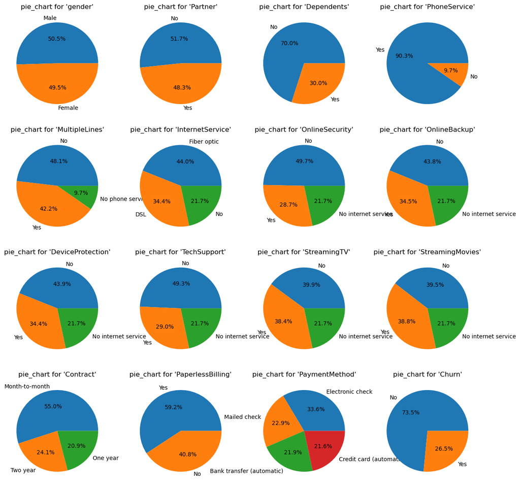

```python
pie_chart(churn)
```

### 2.d) Observations

- In 'Gender' column both 'male' and 'female' classes have same counts approximately.
- The percentage of 'Partner' - 'Yes' is 48.3% and 'No' is 51.7%.
- 'Dependents' columns has maximum counts of 'No'(70%).
- In 'MultipleLines', OnlineSecurity', 'OnlineBackup', 'DeviceProtection', 'Techsupport', StreamingTV', 'StreamingMovies' the counts of 'yes' are less than counts of the 'no' assumuning all are as 'No' except 'yes'.
- In 'Contract' column month_to_month occupied 55.0%, Two year is 24.1% and One year is 20.9%.
- In 'PaperlessBilling', 'yes' percentage is 59.2%.
- In the resopnse variable the counts of 'No' are higher than the counts of 'yes', so there is some imbalance in the output varaible.

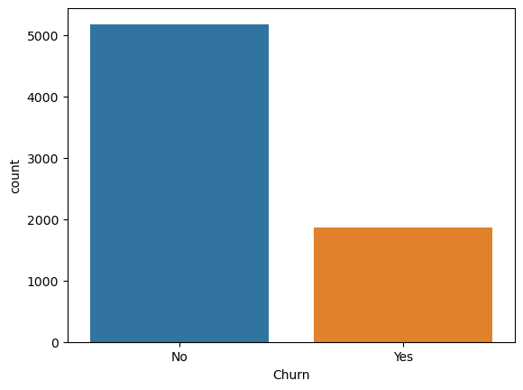

```python
sns.countplot(data = churn, x = 'Churn')
```

### 2.e) Let's encode all the appropriate Categorical features with the best suitable approach.

```python
li = []
for col in churn.columns:
    if col != 'customerID' and churn[col].dtype == 'object':
        churn[col] = churn[col].astype('category')
        li.append(col)
```

```python
for i in li:
    print(churn[i].value_counts(), '\n******************************')
```

```
gender
Male      3555
Female    3488
Name: count, dtype: int64
Partner
No     3641
Yes    3402
Name: count, dtype: int64
Dependents
No     4933
Yes    2110
Name: count, dtype: int64
PhoneService
Yes    6361
No      682
Name: count, dtype: int64
MultipleLines
No                  3390
Yes                 2971
No phone service     682
Name: count, dtype: int64
InternetService
Fiber optic    3096
DSL            2421
No             1526
Name: count, dtype: int64
OnlineSecurity
No                     3498
Yes                    2019
No internet service    1526
Name: count, dtype: int64
OnlineBackup
No                     3088
Yes                    2429
No internet service    1526
Name: count, dtype: int64
DeviceProtection
No                     3095
Yes                    2422
No internet service    1526
```

[output cut: 20 more lines]

```
Name: count, dtype: int64
PaperlessBilling
Yes    4171
No     2872
Name: count, dtype: int64
PaymentMethod
Electronic check             2365
Mailed check                 1612
Bank transfer (automatic)    1544
Credit card (automatic)      1522
Name: count, dtype: int64
Churn
No     5174
Yes    1869
Name: count, dtype: int64
```

```python
churn['gender'] = churn['gender'].apply(lambda x: 0 if x == 'Male' else 1)
churn['Partner'] = churn['Partner'].apply(lambda x: 0 if x == 'No' else 1)
churn['Dependents'] = churn['Dependents'].apply(lambda x: 0 if x == 'No' else 1)
churn['PhoneService'] = churn['PhoneService'].apply(lambda x: 0 if x == 'No' else 1)
churn['MultipleLines'] = churn['MultipleLines'].apply(lambda x: 1 if x == 'Yes' else 0)
churn['InternetService'] = churn['InternetService'].apply(lambda x: 0 if x == 'No' else(1 if x == 'Fiber optic' else 2))
churn['OnlineSecurity'] = churn['OnlineSecurity'].apply(lambda x: 1 if x == 'Yes' else 0)
churn['OnlineBackup'] = churn['OnlineBackup'].apply(lambda x: 1 if x == 'Yes' else 0)
churn['DeviceProtection'] = churn['DeviceProtection'].apply(lambda x: 1 if x == 'Yes' else 0)
churn['TechSupport'] = churn['TechSupport'].apply(lambda x: 1 if x == 'Yes' else 0)
churn['StreamingTV'] = churn['StreamingTV'].apply(lambda x: 1 if x == 'Yes' else 0)
churn['StreamingMovies'] = churn['StreamingMovies'].apply(lambda x: 1 if x == 'Yes' else 0)
churn['Contract'] = churn['Contract'].apply(lambda x: 0 if x == 'Month-to-month' else (1 if x == 'One year' else 2))
churn['PaperlessBilling'] = churn['PaperlessBilling'].apply(lambda x: 1 if x == 'Yes' else 0)
churn['Churn'] = churn['Churn'].apply(lambda x: 1 if x == 'Yes' else 0)
```

- Create dummy variables for 'PaymentMethod'.

```python
churn = pd.get_dummies(churn, columns = ['PaymentMethod'], dtype=int)
```

```python
churn.shape
```

```
(7043, 24)
```

### 2.f) Let's split the data into training and testing

```python
X = churn.drop(['customerID', 'Churn'], axis = 1)
y = churn[['Churn']]
```

```python
from sklearn.model_selection import train_test_split
X_train, X_test, y_train, y_test = train_test_split(X, y, test_size = 0.20, random_state = 42, stratify = y)
```

```python
y_train.value_counts(normalize = True)
```

```
Churn
0        0.734647
1        0.265353
Name: proportion, dtype: float64
```

### 2.g) Let's Standarize the data

```python
from sklearn.preprocessing import StandardScaler
scaler = StandardScaler()
X_train = scaler.fit_transform(X_train)
X_test = scaler.transform(X_test)
```

## MODEL BUILDING

### 3.a) Let's bulid a Decision Tree

- Let's create a function to print all the metrics of the model.

```python
from sklearn.metrics import *
# Function to print all the metrics of the model.
def metrics_function(y_actual, y_pred):
    Accuracy_Score  = accuracy_score(y_actual, y_pred)
    Precision_Score = precision_score(y_actual, y_pred)
    Recall_Score =  recall_score(y_actual, y_pred)
    F1_Score = f1_score(y_actual, y_pred)
    AUC_Score = roc_auc_score(y_actual, y_pred)
    return Accuracy_Score, Precision_Score, Recall_Score, F1_Score, AUC_Score
```

```python
# Function for confusion_matrix.
def cf_matrix(y_actual, y_pred):
    cm = confusion_matrix(y_actual, y_pred)
    cm = pd.DataFrame(cm, index = ['Actual-No', 'Actual-yes'], columns = ['Pred-No', 'Pred-Yes'])
    plt.figure(figsize = (3,2))
    sns.heatmap(cm, annot = True, cbar = False, fmt = 'g')
    plt.show()
```

```python
from sklearn.tree import DecisionTreeClassifier, plot_tree
tree_1 = DecisionTreeClassifier(random_state = 1)
start = time.time()
tree_1 = tree_1.fit(X_train, y_train)
end = time.time()
execusion_time = end - start
```

```python
plt.figure(figsize=(10,5), dpi = 1000)
plot_tree(tree_1, filled=True, feature_names=X.columns, max_depth = 3, class_names = ['0','1'])
plt.show()
```

[figure not shown]

```python
y_train_predict = tree_1.predict(X_train)
y_test_predict = tree_1.predict(X_test)
```

```python
dt_train_scores = metrics_function(y_train, y_train_predict)
dt_test_scores = metrics_function(y_test, y_test_predict)
li_2 = ['Accuracy', 'Precision', 'Recall', 'f1_score', 'AUC_score']
for i, j, k in zip(li_2,dt_train_scores, dt_test_scores):
    print('Train', i , ' = ', j)
    print('Test', i , ' = ', k,'\n')
dt_test_scores = [i for i in dt_test_scores]
dt_test_scores.append(execusion_time)
```

```
Train Accuracy  =  0.9980475683351083
Test Accuracy  =  0.7317246273953159

Train Precision  =  0.9993270524899058
Test Precision  =  0.49476439790575916

Train Recall  =  0.9933110367892977
Test Recall  =  0.5053475935828877

Train f1_score  =  0.996309963099631
Test f1_score  =  0.5

Train AUC_score  =  0.9965347162685314
Test AUC_score  =  0.6594370818155985
```

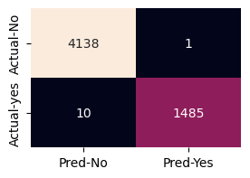

```python
cf_matrix(y_train, y_train_predict)
```

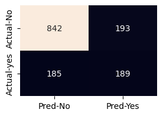

```python
cf_matrix(y_test, y_test_predict)
```

### 3.b) Let's tune the Hyper_Parameters of the DecisionTreeClassifier using GridSearchCV

```python
from sklearn.model_selection import GridSearchCV

parameters = {'min_samples_leaf':[100,200,300],
             'max_depth':[1,3,5,7],
              'criterion':['gini', 'entropy'],
              'max_features':[0.2,0.3,0.4,0.5],
              'min_samples_split':[100,200,300,400,500]
             }
tree_tuning = GridSearchCV(DecisionTreeClassifier(random_state = 1), param_grid = parameters, cv = 5, scoring = make_scorer(recall_score))
```

```python
start = time.time()
tree_tuning = tree_tuning.fit(X_train, y_train)
end = time.time()
execusion_time = end - start
```

```python
print("Best Parameters are : ", tree_tuning.best_params_, '\n')
tuning_test = tree_tuning.predict(X_test)
tuning_train = tree_tuning.predict(X_train)
tuning_train_scores = metrics_function(y_train, tuning_train)
tuning_test_scores = metrics_function(y_test, tuning_test)
for i, j, k in zip(li_2,tuning_train_scores, tuning_test_scores):
    print('Train', i , ' = ', j)
    print('Test', i , ' = ', k,'\n')
tuning_test_scores = [i for i in tuning_test_scores]
tuning_test_scores.append(execusion_time)
```

```
Best Parameters are :  {'criterion': 'entropy', 'max_depth': 7, 'max_features': 0.2, 'min_samples_leaf': 200, 'min_samples_split': 500}

Train Accuracy  =  0.7765353212637558
Test Accuracy  =  0.7643718949609652

Train Precision  =  0.6191919191919192
Test Precision  =  0.5867768595041323

Train Recall  =  0.4100334448160535
Test Recall  =  0.37967914438502676

Train f1_score  =  0.49336016096579477
Test f1_score  =  0.461038961038961

Train AUC_score  =  0.6594743208617596
Test AUC_score  =  0.641530393448552
```

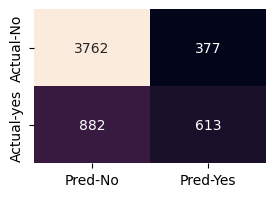

```python
cf_matrix(y_train, tuning_train)
```

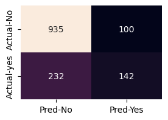

```python
cf_matrix(y_test, tuning_test)
```

### 3.c) Let's model the data using a RandomForestClassifier

```python
from sklearn.ensemble import RandomForestClassifier
forest_1 = RandomForestClassifier(random_state = 1)
start = time.time()
forest_1 = forest_1.fit(X_train, y_train)
end = time.time()
execution_time = end - start
forest_train_pred = forest_1.predict(X_train)
forest_test_pred = forest_1.predict(X_test)
```

```python
rf_train_scores = metrics_function(y_train, forest_train_pred)
rf_test_scores = metrics_function(y_test, forest_test_pred)
for i, j, k in zip(li_2,rf_train_scores, rf_test_scores):
    print('Train', i , ' = ', j)
    print('Test', i , ' = ', k,'\n')
rf_test_scores = [i for i in rf_test_scores]
rf_test_scores.append(execution_time)
```

```
Train Accuracy  =  0.9980475683351083
Test Accuracy  =  0.7842441447835344

Train Precision  =  0.9979865771812081
Test Precision  =  0.6151315789473685

Train Recall  =  0.9946488294314382
Test Recall  =  0.5

Train f1_score  =  0.9963149078726968
Test f1_score  =  0.551622418879056

Train AUC_score  =  0.9969620083373668
Test AUC_score  =  0.6934782608695651
```

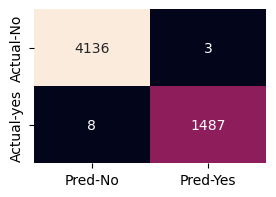

```python
cf_matrix(y_train, forest_train_pred)
```

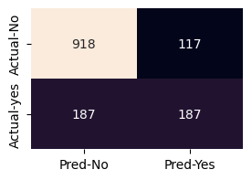

```python
cf_matrix(y_test, forest_test_pred)
```

### 3.d) Let's tune the Hyper_parameters of the base Random Forest Model

```python
# Let's tune the class_weights as we have only a few 'yes' in the output variable.
param_grid = {'n_estimators':[10,50,100,200],
             'max_features':[0.3, 0.4, 0.5, 0.7],
             'max_samples' :[0.3, 0.5, 0.9, 1.0],
             'max_depth':[1,2],
             'class_weight':[{0:0.4, 1:0.6}]}
grid_forest = GridSearchCV(estimator = RandomForestClassifier(random_state = 1), param_grid = param_grid, cv = 5, scoring = make_scorer(recall_score))
```

```python
start = time.time()
grid_forest.fit(X_train, y_train)
end = time.time()
execution_time = end - start
```

```python
print("Best Parameters are : ", grid_forest.best_params_, '\n')
forest_train = grid_forest.predict(X_train)
forest_test = grid_forest.predict(X_test)
tuned_rf_train= metrics_function(y_train, forest_train)
tuned_rf_test = metrics_function(y_test, forest_test)
for i, j, k in zip(li_2,tuned_rf_train, tuned_rf_test):
    print('Train', i , ' = ', j)
    print('Test', i , ' = ', k,'\n')
tuned_rf_test = [i for i in tuned_rf_test]
tuned_rf_test.append(execution_time)
```

```
Best Parameters are :  {'class_weight': {0: 0.4, 1: 0.6}, 'max_depth': 2, 'max_features': 0.7, 'max_samples': 0.5, 'n_estimators': 10}

Train Accuracy  =  0.759318423855165
Test Accuracy  =  0.7466288147622427

Train Precision  =  0.5377922784121806
Test Precision  =  0.5185995623632386

Train Recall  =  0.6615384615384615
Test Recall  =  0.6336898395721925

Train f1_score  =  0.5932813437312537
Test f1_score  =  0.5703971119133574

Train AUC_score  =  0.728087423569424
Test AUC_score  =  0.7105647265493813
```

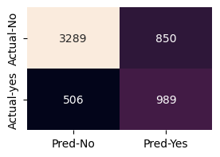

```python
cf_matrix(y_train, forest_train)
```

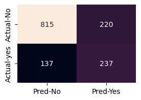

```python
cf_matrix(y_test, forest_test)
```

### Observations

- In base RandomForestClassifier model the average scores of training data is 99%.But in testing data Accuracy is 78%, Recall is 50% and Precision Score is 61%.
- We can observe that there is overfitting in base estimator.
- After tuning the Hyper Parameters Train Accuracy decreased to 75%, Precision score is 53% and Recall Score 66% on training data.
- After tuning test Recall is increased to 63%.

### 3.e) Let's model the data with Ada Boost Classifier

```python
from sklearn.ensemble import AdaBoostClassifier
ada_boost = AdaBoostClassifier(random_state = 1)
start = time.time()
ada_boost.fit(X_train, y_train)
end = time.time()
execution_time = end - start
ada_train_pred = ada_boost.predict(X_train)
ada_test_pred = ada_boost.predict(X_test)
```

```python
train_scores_ada = metrics_function(y_train, ada_train_pred)
test_scores_ada = metrics_function(y_test, ada_test_pred)
for i, j, k in zip(li_2,train_scores_ada, test_scores_ada):
    print('Train', i , ' = ', j)
    print('Test', i , ' = ', k,'\n')
test_scores_ada = [i for i in test_scores_ada]
test_scores_ada.append(execution_time)
```

```
Train Accuracy  =  0.8081292154774583
Test Accuracy  =  0.8062455642299503

Train Precision  =  0.6688417618270799
Test Precision  =  0.6644951140065146

Train Recall  =  0.5484949832775919
Test Recall  =  0.5454545454545454

Train f1_score  =  0.6027195883866225
Test f1_score  =  0.5991189427312775

Train AUC_score  =  0.7252018284351237
Test AUC_score  =  0.7229688186209925
```

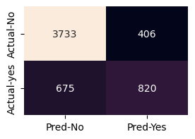

```python
cf_matrix(y_train, ada_train_pred)
```

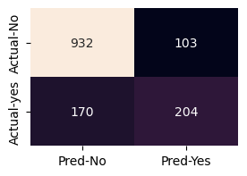

```python
cf_matrix(y_test, ada_test_pred)
```

### 3.f) Let's tune the HyperParameters using GridsearchCV

```python
params = {'n_estimators':[10,25,50,100,200],
         'learning_rate':[0.001, 0.01, 0.1, 1.0]}
base_model = AdaBoostClassifier(random_state = 1)
ada_search = GridSearchCV(base_model, param_grid = params, cv = 5, scoring = make_scorer(recall_score))
```

```python
start = time.time()
ada_search.fit(X_train, y_train)
end = time.time()
execution_time = end - start
```

```python
print("Best params = ", ada_search.best_params_, '\n')
ada_train = ada_search.predict(X_train)
ada_test = ada_search.predict(X_test)
tuned_ada_train = metrics_function(y_train, ada_train)
tuned_ada_test = metrics_function(y_test, ada_test)
for i, j, k in zip(li_2,tuned_ada_train, tuned_ada_test):
    print('Train', i , ' = ', j)
    print('Test', i , ' = ', k,'\n')
tuned_ada_test = [i for i in tuned_ada_test]
tuned_ada_test.append(execution_time)
```

```
Best params =  {'learning_rate': 1.0, 'n_estimators': 10}

Train Accuracy  =  0.7909123180688676
Test Accuracy  =  0.7899219304471257

Train Precision  =  0.6222050886661527
Test Precision  =  0.6181818181818182

Train Recall  =  0.539799331103679
Test Recall  =  0.5454545454545454

Train f1_score  =  0.578080229226361
Test f1_score  =  0.5795454545454546

Train AUC_score  =  0.7107066237543038
Test AUC_score  =  0.7118577075098814
```

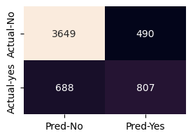

```python
cf_matrix(y_train, ada_train)
```

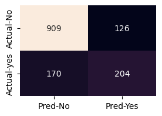

```python
cf_matrix(y_test, ada_test)
```

### Observations

- In base Ada boost classifier both testing and training accuracies are 80%, Precision scores are 66% and Recall scores are 54%.
- After tuning the hyper parameters, both training and testing Accuracies are decresed a bit.
- The model is predicting 54% of the True positives.
- So, the base AdaBoost model is giving good scores.

### 3.g) Let's train a GradientBoostClassifier

```python
from sklearn.ensemble import GradientBoostingClassifier
gradient_boost = GradientBoostingClassifier()
start = time.time()
gradient_boost.fit(X_train, y_train)
end = time.time()
execution_time = end - start
gradient_test_pred = gradient_boost.predict(X_test)
gradient_train_pred = gradient_boost.predict(X_train)
```

```python
gradient_train = metrics_function(y_train, gradient_train_pred)
gradient_test = metrics_function(y_test, gradient_test_pred)
for i, j, k in zip(li_2,gradient_train, gradient_test):
    print('Train', i , ' = ', j)
    print('Test', i , ' = ', k,'\n')
gradient_test = [i for i in gradient_test]
gradient_test.append(execution_time)
```

```
Train Accuracy  =  0.8285410010649628
Test Accuracy  =  0.8026969481902059

Train Precision  =  0.7298001737619462
Test Precision  =  0.6690140845070423

Train Recall  =  0.5618729096989966
Test Recall  =  0.5080213903743316

Train f1_score  =  0.6349206349206349
Test f1_score  =  0.5775075987841946

Train AUC_score  =  0.7433669936269809
Test AUC_score  =  0.7086000671678421
```

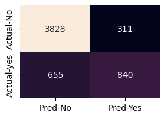

```python
cf_matrix(y_train, gradient_train_pred)
```

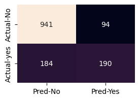

```python
cf_matrix(y_test, gradient_test_pred)
```

### 3.h) Let's tune the Hyper parameters using GridSearchCV

```python
params = {'n_estimators':[10, 50,100,200, 250],
         'learning_rate':[0.001, 0.01, 0.1, 1.0],
         'max_depth':[1,2],
         'max_features':[0.3, 0.5, 0.7]}
gradient_search = GridSearchCV(GradientBoostingClassifier(random_state = 1), param_grid = params, cv = 5, scoring = make_scorer(recall_score))
```

```python
start = time.time()
gradient_search.fit(X_train, y_train)
end = time.time()
execution_time = end - start
```

```python
print("Best params = ", gradient_search.best_params_, '\n')
gradient_test2 = gradient_search.predict(X_test)
gradient_train2 = gradient_search.predict(X_train)
tuned_gradient_train = metrics_function(y_train, gradient_train2)
tuned_gradient_test = metrics_function(y_test, gradient_test2)
for i, j, k in zip(li_2,tuned_gradient_train, tuned_gradient_test):
    print('Train', i , ' = ', j)
    print('Test', i , ' = ', k,'\n')
tuned_gradient_test = [i for i in tuned_gradient_test]
tuned_gradient_test.append(execution_time)
```

```
Best params =  {'learning_rate': 1.0, 'max_depth': 1, 'max_features': 0.7, 'n_estimators': 250}

Train Accuracy  =  0.8194888178913738
Test Accuracy  =  0.8048261178140526

Train Precision  =  0.7018581081081081
Test Precision  =  0.6612377850162866

Train Recall  =  0.5558528428093645
Test Recall  =  0.5427807486631016

Train f1_score  =  0.620380739081747
Test f1_score  =  0.5961820851688693

Train AUC_score  =  0.7352832708852332
Test AUC_score  =  0.7211488284378309
```

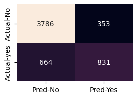

```python
cf_matrix(y_train, gradient_train2)
```

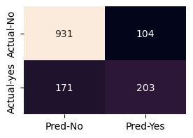

```python
cf_matrix(y_test, gradient_test2)
```

### Observations

- The base GradientBoost model's Accuracy is 82% on traing data and 80% on testing data.
- Only 50% of the True positives are the predicted by the model out of all the actual positives.
- After tuning the parameters test Recall score increased to 54%.
- In base model True positive counts are 190 after tuning increased to 203.

#### Let's create a dataframe to store all model's testing scores.

```python
df = pd.DataFrame(columns = ['Decision tree', 'Tuned tree', 'Random forest', 'Tuned forest',
                             'Ada boost', 'Tuned ada', 'Gradient boost', 'Tuned gradient'],
                  index = ['Accuracy', 'Precision', 'Recall', 'F1_score', 'AUC_score', 'Elapsed'])
```

```python
df['Decision tree'] = dt_test_scores
df['Tuned tree'] = tuning_test_scores
df['Random forest'] = rf_test_scores
df['Tuned forest'] = tuned_rf_test
df['Ada boost'] = test_scores_ada
df['Tuned ada'] = tuned_ada_test
df['Gradient boost'] = gradient_test
df['Tuned gradient'] = tuned_gradient_test
```

```python
df
```

|  | Decision tree | Tuned tree | Random forest | Tuned forest | Ada boost | Tuned ada | Gradient boost | Tuned gradient |
| --- | --- | --- | --- | --- | --- | --- | --- | --- |
| Accuracy | 0.731725 | 0.764372 | 0.784244 | 0.746629 | 0.806246 | 0.789922 | 0.802697 | 0.804826 |
| Precision | 0.494764 | 0.586777 | 0.615132 | 0.518600 | 0.664495 | 0.618182 | 0.669014 | 0.661238 |
| Recall | 0.505348 | 0.379679 | 0.500000 | 0.633690 | 0.545455 | 0.545455 | 0.508021 | 0.542781 |
| F1_score | 0.500000 | 0.461039 | 0.551622 | 0.570397 | 0.599119 | 0.579545 | 0.577508 | 0.596182 |
| AUC_score | 0.659437 | 0.641530 | 0.693478 | 0.710565 | 0.722969 | 0.711858 | 0.708600 | 0.721149 |
| Elapsed | 0.031914 | 30.475200 | 0.685136 | 151.056967 | 0.273006 | 42.278969 | 0.888566 | 209.517002 |

### 2) Best Model

- According to the Problem statement, our goal is to predict the customers who are going to churn.
- Tuned Random Forest model is predicting more True Positives comparing with the other models.
- Accuracy scores of traing and testing data are also close to each other.
- None of the model is giving 63% of Recall score except Randomforest model.
- According to the Accuracy score AdaBoost and GradientBoost models are performing well.

### 3) Why this model is performing well?

- While tuning the Hyper parameters of the Random Forest model the class_weights ratio set to 0.4:0.6 ratio.
- So, the model is more effective in predicting the class-'Yes'.

### 4) Conclusion

- Here our objective is to find maximum no of counts that who are going to churn.
- So, After tuning random forest classifier is giving good Recall score(63%) comparing with other models.
- Therefore, tuned Random forest classifier is predicting maximum counts of the customers who are going to churn.